# Neural Network Approach to Employee Attrition Analysis

Dimas Aditya

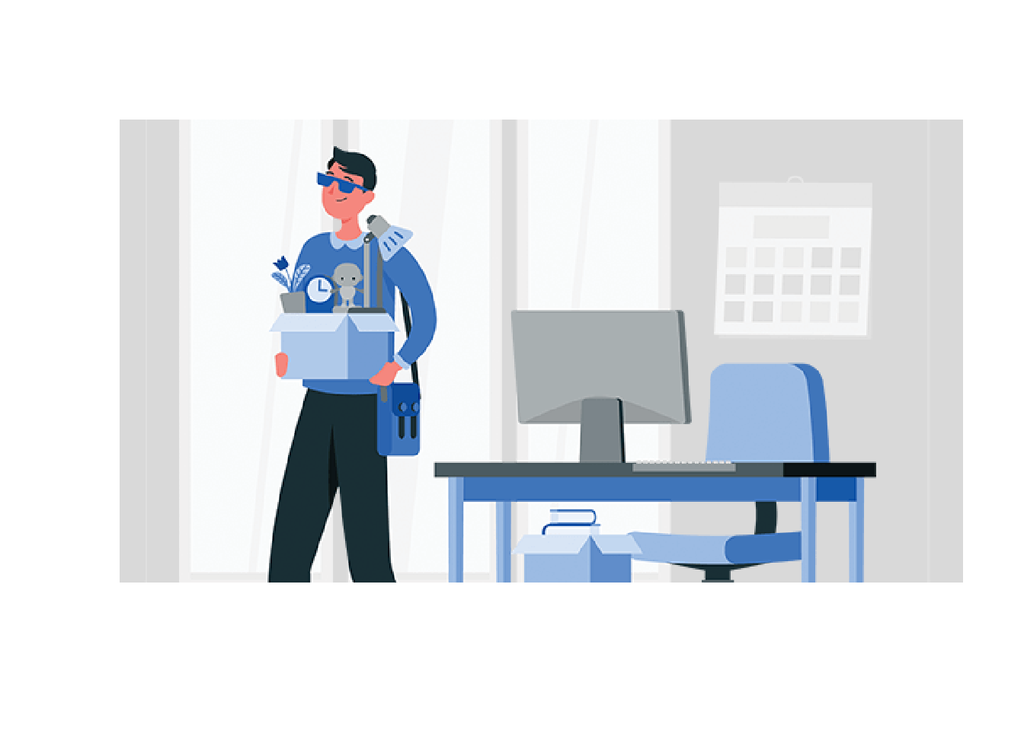

# Description

The dataset under examination comprises 1,470 employees and includes 35 attributes that offer insights into various factors influencing employee attrition. Key variables encompass demographic information (such as age, gender, and marital status), job-related metrics (including job role, level, and satisfaction), and compensation details (such as monthly income and hourly rate). Additionally, the dataset captures factors related to employee work environment and career progression, including distance from home, job involvement, and years with the current manager. This rich dataset is instrumental in understanding the dynamics of employee turnover and identifying critical factors that contribute to attrition, enabling targeted interventions to improve employee retention and organizational stability.

Source: https://www.kaggle.com/pavansubhasht/ibm-hr-analytics-attrition-dataset

# Business Question

# Variable Description

|  | Variable | Data.Type | Role | Description | Example |
| --- | --- | --- | --- | --- | --- |
| 1 | Age | Integer | Predictor | Age of the employee | 41 |
| 2 | Attrition | Character | Target | Whether the employee left the company (Yes, No) | Yes |
| 3 | BusinessTravel | Character | Predictor | Frequency of business travel (Non-Travel, Travel_Rarely, Travel_Frequently) | Travel_Rarely |
| 4 | DailyRate | Integer | Predictor | Amount paid per day of work | 1102 |
| 5 | Department | Character | Predictor | Work department (Research and Development, Sales, Human Resources) | Sales |
| 6 | DistanceFromHome | Integer | Predictor | Distance between company and home | 1 |
| 7 | Education | Integer | Predictor | Level of education (1: Below College, 2: College, 3: Bachelor, 4: Master, 5: Doctor) | 2 |
| 8 | EducationField | Character | Predictor | Field of education (Life Sciences, Medical, Human Resources, Technical Degree, Marketing, Other) | Life Sciences |
| 9 | EmployeeCount | Integer | Identifier | Count of employees (always 1) | 1 |
| 10 | EmployeeNumber | Integer | Identifier | ID of the employee | 1 |

[output cut: 25 more lines]

# 1. Data Preparation

## 1.1 Prerequisites

## 1.2 Importing Libraries

```r
set.seed(314)
library(tidyverse)
library(factoextra)
library(FactoMineR)
library(ggiraphExtra)
library(rsample)
library(caret)
library(keras)
```

## 1.3 Importing Dataset

```r
employee <- read.csv("data_input/HRA.csv", stringsAsFactors = T)
head(employee)
```

```
##   Age Attrition    BusinessTravel DailyRate             Department
## 1  41       Yes     Travel_Rarely      1102                  Sales
## 2  49        No Travel_Frequently       279 Research & Development
## 3  37       Yes     Travel_Rarely      1373 Research & Development
## 4  33        No Travel_Frequently      1392 Research & Development
## 5  27        No     Travel_Rarely       591 Research & Development
## 6  32        No Travel_Frequently      1005 Research & Development
##   DistanceFromHome Education EducationField EmployeeCount EmployeeNumber
## 1                1         2  Life Sciences             1              1
## 2                8         1  Life Sciences             1              2
## 3                2         2          Other             1              4
## 4                3         4  Life Sciences             1              5
## 5                2         1        Medical             1              7
## 6                2         2  Life Sciences             1              8
##   EnvironmentSatisfaction Gender HourlyRate JobInvolvement JobLevel
```

[output cut: 41 more lines]

## 1.4 Data Inspection

```r
glimpse(employee)
```

```
## Rows: 1,470
## Columns: 35
## $ Age                      <int> 41, 49, 37, 33, 27, 32, 59, 30, 38, 36, 35, 2…
## $ Attrition                <fct> Yes, No, Yes, No, No, No, No, No, No, No, No,…
## $ BusinessTravel           <fct> Travel_Rarely, Travel_Frequently, Travel_Rare…
## $ DailyRate                <int> 1102, 279, 1373, 1392, 591, 1005, 1324, 1358,…
## $ Department               <fct> Sales, Research & Development, Research & Dev…
## $ DistanceFromHome         <int> 1, 8, 2, 3, 2, 2, 3, 24, 23, 27, 16, 15, 26, …
## $ Education                <int> 2, 1, 2, 4, 1, 2, 3, 1, 3, 3, 3, 2, 1, 2, 3, …
## $ EducationField           <fct> Life Sciences, Life Sciences, Other, Life Sci…
## $ EmployeeCount            <int> 1, 1, 1, 1, 1, 1, 1, 1, 1, 1, 1, 1, 1, 1, 1, …
## $ EmployeeNumber           <int> 1, 2, 4, 5, 7, 8, 10, 11, 12, 13, 14, 15, 16,…
## $ EnvironmentSatisfaction  <int> 2, 3, 4, 4, 1, 4, 3, 4, 4, 3, 1, 4, 1, 2, 3, …
## $ Gender                   <fct> Female, Male, Male, Female, Male, Male, Femal…
## $ HourlyRate               <int> 94, 61, 92, 56, 40, 79, 81, 67, 44, 94, 84, 4…
```

[output cut: 22 more lines]

## 1.5 Data Types

```r
employee_clean <- employee %>%
  select(-c("EmployeeCount", "Over18", "StandardHours", "EmployeeNumber"))

unique(employee$EmployeeCount)
```

```
## [1] 1
```

```r
unique(employee$JobInvolvement)
```

```
## [1] 3 2 4 1
```

```r
unique(employee$JobLevel)
```

```
## [1] 2 1 3 4 5
```

```r
unique(employee$Over18)
```

```
## [1] Y
## Levels: Y
```

```r
summary(employee)
```

```
##       Age        Attrition            BusinessTravel   DailyRate
##  Min.   :18.00   No :1233   Non-Travel       : 150   Min.   : 102.0
##  1st Qu.:30.00   Yes: 237   Travel_Frequently: 277   1st Qu.: 465.0
##  Median :36.00              Travel_Rarely    :1043   Median : 802.0
##  Mean   :36.92                                       Mean   : 802.5
##  3rd Qu.:43.00                                       3rd Qu.:1157.0
##  Max.   :60.00                                       Max.   :1499.0
##
##                   Department  DistanceFromHome   Education
##  Human Resources       : 63   Min.   : 1.000   Min.   :1.000
##  Research & Development:961   1st Qu.: 2.000   1st Qu.:2.000
##  Sales                 :446   Median : 7.000   Median :3.000
##                               Mean   : 9.193   Mean   :2.913
##                               3rd Qu.:14.000   3rd Qu.:4.000
##                               Max.   :29.000   Max.   :5.000
##
##           EducationField EmployeeCount EmployeeNumber   EnvironmentSatisfaction
##  Human Resources : 27    Min.   :1     Min.   :   1.0   Min.   :1.000
##  Life Sciences   :606    1st Qu.:1     1st Qu.: 491.2   1st Qu.:2.000
##  Marketing       :159    Median :1     Median :1020.5   Median :3.000
##  Medical         :464    Mean   :1     Mean   :1024.9   Mean   :2.722
##  Other           : 82    3rd Qu.:1     3rd Qu.:1555.8   3rd Qu.:4.000
##  Technical Degree:132    Max.   :1     Max.   :2068.0   Max.   :4.000
##
##     Gender      HourlyRate     JobInvolvement    JobLevel
##  Female:588   Min.   : 30.00   Min.   :1.00   Min.   :1.000
##  Male  :882   1st Qu.: 48.00   1st Qu.:2.00   1st Qu.:1.000
##               Median : 66.00   Median :3.00   Median :2.000
##               Mean   : 65.89   Mean   :2.73   Mean   :2.064
##               3rd Qu.: 83.75   3rd Qu.:3.00   3rd Qu.:3.000
##               Max.   :100.00   Max.   :4.00   Max.   :5.000
##
##                       JobRole    JobSatisfaction  MaritalStatus MonthlyIncome
##  Sales Executive          :326   Min.   :1.000   Divorced:327   Min.   : 1009
##  Research Scientist       :292   1st Qu.:2.000   Married :673   1st Qu.: 2911
##  Laboratory Technician    :259   Median :3.000   Single  :470   Median : 4919
##  Manufacturing Director   :145   Mean   :2.729                  Mean   : 6503
##  Healthcare Representative:131   3rd Qu.:4.000                  3rd Qu.: 8379
##  Manager                  :102   Max.   :4.000                  Max.   :19999
##  (Other)                  :215
```

[output cut: 17 more lines]

```
##  Min.   : 0.00     Min.   :0.000         Min.   :1.000   Min.   : 0.000
##  1st Qu.: 6.00     1st Qu.:2.000         1st Qu.:2.000   1st Qu.: 3.000
##  Median :10.00     Median :3.000         Median :3.000   Median : 5.000
##  Mean   :11.28     Mean   :2.799         Mean   :2.761   Mean   : 7.008
##  3rd Qu.:15.00     3rd Qu.:3.000         3rd Qu.:3.000   3rd Qu.: 9.000
##  Max.   :40.00     Max.   :6.000         Max.   :4.000   Max.   :40.000
##
##  YearsInCurrentRole YearsSinceLastPromotion YearsWithCurrManager
##  Min.   : 0.000     Min.   : 0.000          Min.   : 0.000
##  1st Qu.: 2.000     1st Qu.: 0.000          1st Qu.: 2.000
##  Median : 3.000     Median : 1.000          Median : 3.000
##  Mean   : 4.229     Mean   : 2.188          Mean   : 4.123
##  3rd Qu.: 7.000     3rd Qu.: 3.000          3rd Qu.: 7.000
##  Max.   :18.000     Max.   :15.000          Max.   :17.000
##
```

# 2. Handling Missing Values

## 2.1 Missing Value

```r
colSums(is.na(employee_clean))
```

```
##                      Age                Attrition           BusinessTravel
##                        0                        0                        0
##                DailyRate               Department         DistanceFromHome
##                        0                        0                        0
##                Education           EducationField  EnvironmentSatisfaction
##                        0                        0                        0
##                   Gender               HourlyRate           JobInvolvement
##                        0                        0                        0
##                 JobLevel                  JobRole          JobSatisfaction
##                        0                        0                        0
##            MaritalStatus            MonthlyIncome              MonthlyRate
##                        0                        0                        0
##       NumCompaniesWorked                 OverTime        PercentSalaryHike
##                        0                        0                        0
##        PerformanceRating RelationshipSatisfaction         StockOptionLevel
##                        0                        0                        0
##        TotalWorkingYears    TrainingTimesLastYear          WorkLifeBalance
##                        0                        0                        0
##           YearsAtCompany       YearsInCurrentRole  YearsSinceLastPromotion
##                        0                        0                        0
##     YearsWithCurrManager
##                        0
```

# 3. Data Wrangling

## 3.1 Data Transformation

```r
employee_num <- employee_clean %>%
  select_if(is.numeric)
employee_num_scaled <- scale(employee_num)
```

# 4. Exploratory Data Analysis

## 4.1 Base PCA

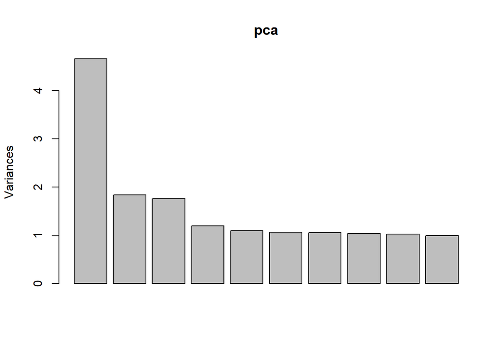

```r
pca <- prcomp(x = employee_num, scale. = T)
plot(pca, label = T)
```

## 4.2 Biplot

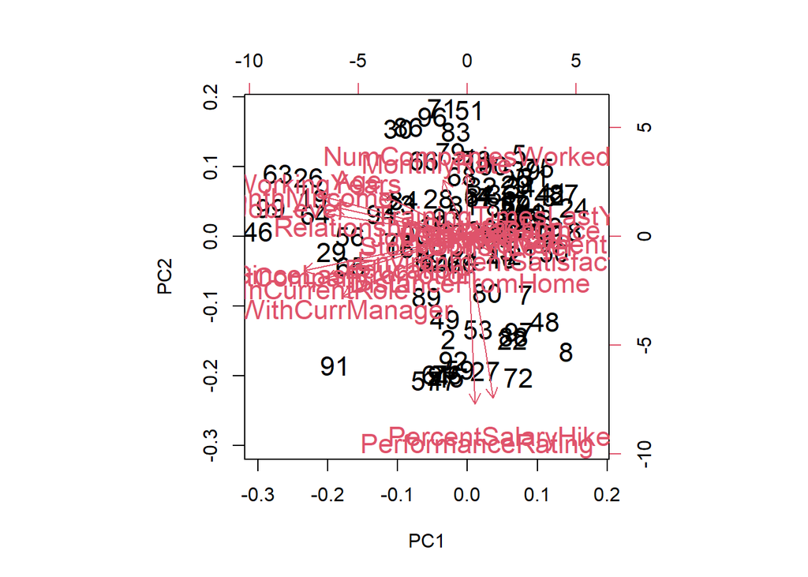

```r
biplot(x = prcomp(employee_num %>% scale() %>% head(100)), cex=1.4)
```

## 4.3 Contribution

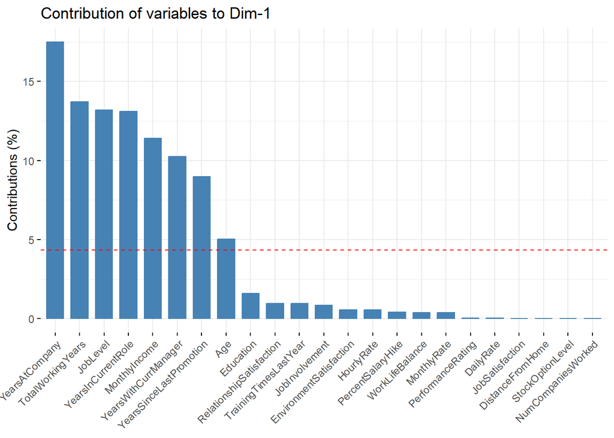

```r
fviz_contrib(
  X = prcomp(employee_num %>% scale() %>% head(100)),
  choice = "var",
  axes = 1
)
```

## 4.4 FactoMineR

```r
qualivar <- c(2,3,5,8,10,14,16,20)
quantivar <- c(1:30)[!c(1:30) %in% qualivar]

employee_pca <- PCA(X = employee_clean,
    scale.unit = T,
    quali.sup = qualivar,
    ncp = 23,
    graph = F)

head(employee_pca$ind$coord)
```

```
##        Dim.1      Dim.2      Dim.3       Dim.4      Dim.5      Dim.6     Dim.7
## 1 -0.3402021 -1.6425344  0.1100639  0.79035276  1.7185598 -1.4744878 0.3235198
## 2  0.6094791  2.5534278  1.9127937 -1.65050159 -1.3792339 -0.3235685 0.4902771
## 3 -2.4205040 -1.1315811  0.4480900 -0.01902049  0.6779377  1.5413090 0.1483998
## 4 -0.8671335 -0.2839553 -1.3820657 -0.55764281  0.3905435  0.3867866 1.4611601
## 5 -1.8951143 -1.1223375 -0.3939562 -0.62741412 -0.8146266  0.9042650 0.4460685
## 6 -0.6072899  0.9053973 -1.7447346 -0.07965912  1.1054204  0.1542838 1.4889031
##        Dim.8      Dim.9      Dim.10      Dim.11      Dim.12      Dim.13
## 1 -1.3971587  0.5591311 -2.71656720  0.59075634 -1.48430683  1.41815322
## 2  0.8520032  1.0811053  0.07483455 -0.41473204  0.53055444  1.31146524
## 3  0.4840149 -0.2652283 -1.67933257 -1.25575534 -0.01562162 -0.33593253
## 4  0.4593693 -0.4916710  0.21216668  1.36703711 -0.10674537 -0.03908637
## 5 -0.5806523  0.5630754  0.02822246 -0.49757189  0.10959459  0.67359554
## 6 -0.5516226  0.2139034 -0.96440791  0.07958235 -0.45396460  0.90433096
##       Dim.14       Dim.15      Dim.16      Dim.17      Dim.18      Dim.19
## 1  0.5790848  0.002514608  1.79267740 -0.09268832  0.83260007  0.05851981
## 2 -0.8091512 -0.478065807 -0.01387224 -1.90034148  0.07800892 -0.14169801
## 3  1.2407232  1.341190640  1.39389024 -0.14769863 -0.27731617  0.12351658
## 4  1.8601876 -0.277377803 -0.54986108  0.06324740 -0.53771863 -1.17503560
## 5 -1.4635249 -2.509889243  2.20042483  0.78034536  0.45339256  0.06691025
## 6  0.4118312  1.270759320  0.12120559 -0.37673990 -0.06362240 -0.26571979
##        Dim.20      Dim.21       Dim.22      Dim.23
## 1 -0.32617741  0.59438195  0.626231307 -0.06270521
## 2  0.09368915  0.55826032  0.404472546 -0.12222444
## 3  0.21470234 -0.14999009 -0.004433548 -0.03718327
## 4 -0.69266787 -0.48663837  0.100428299  0.12997028
## 5 -0.29395462 -0.08193348 -0.023614068  0.18864176
## 6 -0.06111410  0.22260941 -0.386322515  0.16894805
```

## 4.5 PCA Individuals

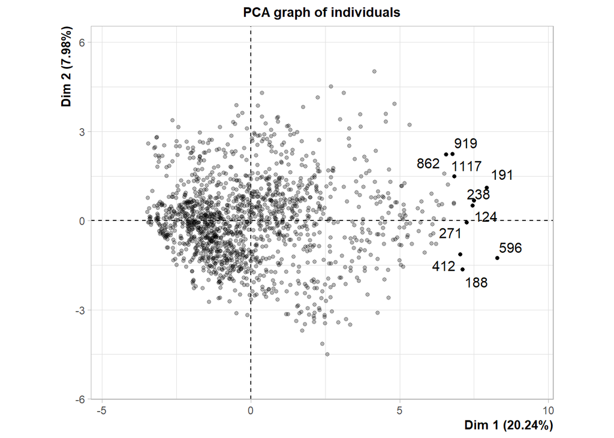

```r
plot.PCA(x = employee_pca,
         choix = "ind",
         select = "contrib10",
         invisible = "quali")
```

## 4.6 PCA Variables

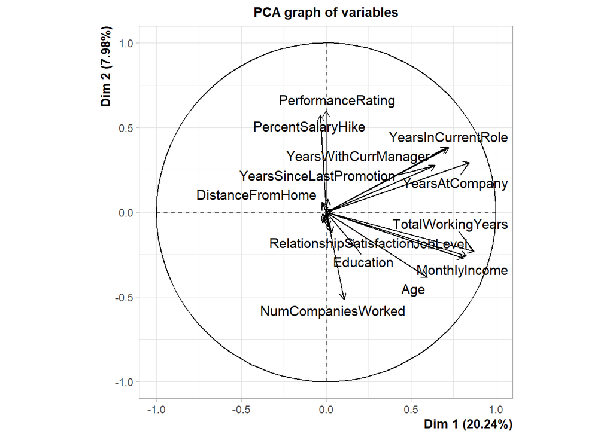

```r
plot.PCA(x = employee_pca, choix = "var", label = "all")
```

## 4.7 Variable Contribution

```r
dim <- dimdesc(employee_pca)

as.data.frame(dim$Dim.1$quanti)
```

```
##                         correlation       p.value
## TotalWorkingYears         0.8705583  0.000000e+00
## YearsAtCompany            0.8447751  0.000000e+00
## JobLevel                  0.8260250  0.000000e+00
## MonthlyIncome             0.8085802  0.000000e+00
## YearsInCurrentRole        0.7248619 7.342664e-240
## YearsWithCurrManager      0.7128950 1.680595e-228
## YearsSinceLastPromotion   0.6417415 2.111727e-171
## Age                       0.5977268 4.273467e-143
## Education                 0.1681454  8.724442e-11
## NumCompaniesWorked        0.1046384  5.831645e-05
```

```r
as.data.frame(dim$Dim.2$quanti)
```

```
##                          correlation       p.value
## PerformanceRating         0.60006294 1.730861e-144
## PercentSalaryHike         0.57470626 5.763050e-130
## YearsWithCurrManager      0.38237187  2.221494e-52
## YearsInCurrentRole        0.38232101  2.297324e-52
## YearsAtCompany            0.29393322  1.104823e-30
## YearsSinceLastPromotion   0.27600778  4.121838e-27
## DistanceFromHome          0.07691673  3.168538e-03
## TrainingTimesLastYear     0.05855275  2.477052e-02
## HourlyRate               -0.06037865  2.060771e-02
## JobInvolvement           -0.06514718  1.247870e-02
## MonthlyRate              -0.08475562  1.143265e-03
## RelationshipSatisfaction -0.11964635  4.226111e-06
## Education                -0.19869805  1.488675e-14
## TotalWorkingYears        -0.23083766  3.123827e-19
## JobLevel                 -0.25909443  5.620386e-24
## MonthlyIncome            -0.27145517  3.027261e-26
## Age                      -0.38400456  7.538725e-53
## NumCompaniesWorked       -0.51407356 5.988350e-100
```

## 4.8 PCA Eigenvalues

```r
employee_pca$eig
```

```
##         eigenvalue percentage of variance cumulative percentage of variance
## comp 1  4.65568301             20.2421000                          20.24210
## comp 2  1.83608877              7.9829947                          28.22509
## comp 3  1.75518507              7.6312394                          35.85633
## comp 4  1.19196184              5.1824428                          41.03878
## comp 5  1.08623652              4.7227675                          45.76154
## comp 6  1.05824417              4.6010616                          50.36261
## comp 7  1.05156065              4.5720028                          54.93461
## comp 8  1.03833464              4.5144985                          59.44911
## comp 9  1.02137212              4.4407483                          63.88986
## comp 10 0.99066276              4.3072294                          68.19708
## comp 11 0.96536641              4.1972452                          72.39433
## comp 12 0.94683080              4.1166557                          76.51099
## comp 13 0.90365332              3.9289275                          80.43991
## comp 14 0.90208602              3.9221131                          84.36203
## comp 15 0.87926425              3.8228881                          88.18491
## comp 16 0.75387072              3.2776988                          91.46261
## comp 17 0.54146306              2.3541872                          93.81680
## comp 18 0.52212983              2.2701297                          96.08693
## comp 19 0.27987064              1.2168289                          97.30376
## comp 20 0.22607818              0.9829486                          98.28671
## comp 21 0.20390815              0.8865572                          99.17326
## comp 22 0.14174295              0.6162737                          99.78954
## comp 23 0.04840611              0.2104613                         100.00000
```

# 5. Neural Network

## 5.1 Proportion Data

```r
prop.table(table(employee_clean$Attrition))
```

```
##
##        No       Yes
## 0.8387755 0.1612245
```

## 5.2 Upsampling and Downsampling

```r
RNGkind(sample.kind = "Rounding")
set.seed(314)

employee_down <- downSample(x = employee_clean %>% select(-Attrition),
                                        y =  employee_clean$Attrition,
                                        yname = "Attrition")

prop.table(table(employee_down$Attrition))
```

```
##
##  No Yes
## 0.5 0.5
```

```r
employee_up <- upSample(x = employee_clean %>% select(-Attrition),
                                        y =  employee_clean$Attrition,
                                        yname = "Attrition")

prop.table(table(employee_up$Attrition))
```

```
##
##  No Yes
## 0.5 0.5
```

# 6. Cross-Validation

```r
RNGkind(sample.kind = "Rounding")
set.seed(314)


emp_index <- initial_split(employee_clean, prop = 0.8, strata = "Attrition")
emp_train <- training(emp_index)
emp_test <- testing(emp_index)


emp_index <- initial_split(employee_down, prop = 0.8, strata = "Attrition")
emp_train_down <- training(emp_index)
emp_test_down <- testing(emp_index)


emp_index <- initial_split(employee_up, prop = 0.8, strata = "Attrition")
emp_train_up <- training(emp_index)
emp_test_up <- testing(emp_index)
```

# 7. Model Building Section A

## 7.1 All Pred, No Down, No Up

### 7.1.1 Pre-processing

```r
emp_train_x <-
  emp_train %>%
  select(-Attrition)

emp_test_x <-
  emp_test %>%
  select(-Attrition)

emp_train_y <-
  emp_train %>%
  select(Attrition)

emp_test_y <-
  emp_test %>%
  select(Attrition)
```

```r
# glimpse(emp_train_x)
# emp_train_x[,c(2,4,7,9,13,15,19)]
emp_train_x_sc <-
  as.data.frame(model.matrix(~., data = emp_train_x)) %>%
  select(-"(Intercept)") %>%
  scale()

emp_test_x_sc <-
  as.data.frame(model.matrix(~., data = emp_test_x)) %>%
  select(-"(Intercept)") %>%
  scale()

emp_train_x_keras <-
  emp_train_x_sc %>%
  array_reshape(dim = dim(emp_train_x_sc))

emp_test_x_keras <-
  emp_test_x_sc %>%
  array_reshape(dim = dim(emp_test_x_sc))

emp_train_y_keras <-
  emp_train_y %>%
  mutate(Attrition = ifelse(Attrition == "Yes",1,0)) %>%
  as.matrix() %>%
  to_categorical()

# emp_test_y_keras <-
#   emp_test_y %>%
#   mutate(Attrition = ifelse(Attrition == "Yes",1,0)) %>%
#   as.matrix() %>%
#   to_categorical()
```

### 7.1.2 Model Fitting

```r
RNGkind(sample.kind = "Rounding")
```

```r
set.seed(314)
initializer <- initializer_random_normal(seed = 314)

model_nn <- keras_model_sequential()

model_nn %>%
  layer_dense(input_shape = 44,
              units =  128,
              activation =  "tanh",
              bias_initializer = initializer,
              kernel_initializer = initializer,
              name =  "hidden1") %>%
  layer_dense(units = 64,
              activation =  "tanh",
              bias_initializer = initializer,
              kernel_initializer = initializer,
              name =  "hidden2") %>%
  layer_dense(units = 32,
              activation = "tanh",
              bias_initializer = initializer,
              kernel_initializer = initializer,
            name = "hidden3") %>%
  layer_dense(units =  2,
              activation = "sigmoid",
              bias_initializer = initializer,
              kernel_initializer = initializer,
              name = "output")

model_nn %>%
  compile(
    loss =  "binary_crossentropy",
    optimizer = optimizer_adam(learning_rate = 0.001),
    metrics =  "accuracy"
  )

history <- model_nn %>%
           fit(emp_train_x_keras,
               emp_train_y_keras,
               epoch = 15,
               batch_size= 200)
```

```
## 6/6 - 1s - loss: 0.6814 - accuracy: 0.8128 - 793ms/epoch - 132ms/step
## 6/6 - 0s - loss: 0.6539 - accuracy: 0.8570 - 50ms/epoch - 8ms/step
## 6/6 - 0s - loss: 0.6113 - accuracy: 0.8315 - 24ms/epoch - 4ms/step
## 6/6 - 0s - loss: 0.5525 - accuracy: 0.8255 - 23ms/epoch - 4ms/step
## 6/6 - 0s - loss: 0.4766 - accuracy: 0.8511 - 24ms/epoch - 4ms/step
## 6/6 - 0s - loss: 0.4010 - accuracy: 0.8791 - 26ms/epoch - 4ms/step
## 6/6 - 0s - loss: 0.3453 - accuracy: 0.8868 - 23ms/epoch - 4ms/step
## 6/6 - 0s - loss: 0.3084 - accuracy: 0.8911 - 25ms/epoch - 4ms/step
## 6/6 - 0s - loss: 0.2903 - accuracy: 0.8953 - 22ms/epoch - 4ms/step
## 6/6 - 0s - loss: 0.2809 - accuracy: 0.8953 - 25ms/epoch - 4ms/step
## 6/6 - 0s - loss: 0.2775 - accuracy: 0.9021 - 26ms/epoch - 4ms/step
## 6/6 - 0s - loss: 0.2718 - accuracy: 0.9038 - 24ms/epoch - 4ms/step
## 6/6 - 0s - loss: 0.2699 - accuracy: 0.9047 - 25ms/epoch - 4ms/step
## 6/6 - 0s - loss: 0.2700 - accuracy: 0.9072 - 29ms/epoch - 5ms/step
## 6/6 - 0s - loss: 0.2681 - accuracy: 0.9098 - 28ms/epoch - 5ms/step
```

```r
summary(model_nn)
```

```
## Model: "sequential"
## ________________________________________________________________________________
##  Layer (type)                       Output Shape                    Param #
## ================================================================================
##  hidden1 (Dense)                    (None, 128)                     5760
##  hidden2 (Dense)                    (None, 64)                      8256
##  hidden3 (Dense)                    (None, 32)                      2080
##  output (Dense)                     (None, 2)                       66
## ================================================================================
## Total params: 16,162
## Trainable params: 16,162
## Non-trainable params: 0
## ________________________________________________________________________________
```

### 7.1.3 Visualization Plot 1

```r
plot(history)
```

[output not shown]

### 7.1.4 Evaluation

```r
pred_nn_test <- predict(model_nn, emp_test_x_keras)
```

```
## 10/10 - 0s - 97ms/epoch - 10ms/step
```

```r
pred_nn_test_label <-
pred_nn_test %>%
  as.data.frame() %>%
  `colnames<-`(0:1) %>%
  transmute(Class = as.factor(ifelse(names(.)[max.col(.)] == "1","Yes","No")))

confusionMatrix(data = pred_nn_test_label$Class, reference = emp_test_y$Attrition, positive = "Yes")
```

```
## Confusion Matrix and Statistics
##
##           Reference
## Prediction  No Yes
##        No  236  27
##        Yes  11  21
##
##                Accuracy : 0.8712
##                  95% CI : (0.8275, 0.9072)
##     No Information Rate : 0.8373
##     P-Value [Acc > NIR] : 0.06380
##
##                   Kappa : 0.4539
##
##  Mcnemar's Test P-Value : 0.01496
##
##             Sensitivity : 0.43750
##             Specificity : 0.95547
##          Pos Pred Value : 0.65625
##          Neg Pred Value : 0.89734
##              Prevalence : 0.16271
##          Detection Rate : 0.07119
##    Detection Prevalence : 0.10847
##       Balanced Accuracy : 0.69648
##
##        'Positive' Class : Yes
##
```

### 7.1.5 Summary Evaluation

Interpretation: While the accuracy is high, this might give a false sense of performance due to data imbalance. The lower Recall indicates that the model misses a significant portion of employees who are at risk of leaving, and the moderate Precision shows that there’s still a considerable rate of false positives.

While the model demonstrates high accuracy, its performance on Recall and Precision suggests room for improvement. The low Recall indicates that the model misses a substantial number of employees who are at risk of leaving, which is crucial for preventive measures. The moderate Precision shows that the model has a fair accuracy in predicting who will leave but still has a notable rate of incorrect predictions. To enhance the model’s utility, especially in a business context focused on attrition management, efforts should be directed toward improving both Recall and Precision. This will ensure the model not only performs well overall but also provides reliable predictions for actionable insights.

## 7.2 All Pred, Downsampling

### 7.2.1 Pre Processing

```r
emp_train_down_x <-
  emp_train_down %>%
  select(-Attrition)

emp_test_down_x <-
  emp_test_down %>%
  select(-Attrition)

emp_train_down_y <-
  emp_train_down %>%
  select(Attrition)

emp_test_down_y <-
  emp_test_down %>%
  select(Attrition)
```

```r
# glimpse(emp_train_x)
# emp_train_x[,c(2,4,7,9,13,15,19)]

emp_train_down_x_sc <- as.data.frame(model.matrix(~., data = emp_train_down_x)) %>%
  select(-"(Intercept)") %>%
  scale()

emp_test_down_x_sc <-
  as.data.frame(model.matrix(~., data = emp_test_down_x)) %>%
  select(-"(Intercept)") %>%
  scale()

emp_train_down_x_keras <-
  emp_train_down_x_sc %>%
  array_reshape(dim = dim(emp_train_down_x_sc))

emp_test_down_x_keras <-
  emp_test_down_x_sc %>%
  array_reshape(dim = dim(emp_test_down_x_sc))

emp_train_down_y_keras <-
  emp_train_down_y %>%
  mutate(Attrition = ifelse(Attrition == "Yes",1,0)) %>%
  as.matrix() %>%
  to_categorical()

# emp_test_y_keras <-
#   emp_test_y %>%
#   mutate(Attrition = ifelse(Attrition == "Yes",1,0)) %>%
#   as.matrix() %>%
#   to_categorical()
```

### 7.2.2 Model Fitting

```r
RNGkind(sample.kind = "Rounding")
```

```r
set.seed(314)
initializer <- initializer_random_normal(seed = 314)

model_nn_down <- keras_model_sequential()

model_nn_down %>%
  layer_dense(input_shape = 44,
              units =  128,
              activation =  "tanh",
              bias_initializer = initializer,
              kernel_initializer = initializer,
              name =  "hidden1") %>%
  layer_dense(units = 64,
              activation =  "tanh",
              bias_initializer = initializer,
              kernel_initializer = initializer,
              name =  "hidden2") %>%
  layer_dense(units = 32,
              activation = "tanh",
              bias_initializer = initializer,
              kernel_initializer = initializer,
            name = "hidden3") %>%
  layer_dense(units =  2,
              activation = "sigmoid",
              bias_initializer = initializer,
              kernel_initializer = initializer,
              name = "output")

model_nn_down %>%
  compile(
    loss =  "binary_crossentropy",
    optimizer = optimizer_adam(learning_rate = 0.001),
    metrics =  "accuracy"
  )

history_down <- model_nn_down %>%
           fit(emp_train_down_x_keras,
               emp_train_down_y_keras,
               epoch = 20,
               batch_size= 100)
```

```
## 4/4 - 1s - loss: 0.6910 - accuracy: 0.5794 - 596ms/epoch - 149ms/step
## 4/4 - 0s - loss: 0.6786 - accuracy: 0.7196 - 13ms/epoch - 3ms/step
## 4/4 - 0s - loss: 0.6599 - accuracy: 0.7593 - 16ms/epoch - 4ms/step
## 4/4 - 0s - loss: 0.6313 - accuracy: 0.7566 - 21ms/epoch - 5ms/step
## 4/4 - 0s - loss: 0.5945 - accuracy: 0.7593 - 24ms/epoch - 6ms/step
## 4/4 - 0s - loss: 0.5590 - accuracy: 0.7698 - 25ms/epoch - 6ms/step
## 4/4 - 0s - loss: 0.5299 - accuracy: 0.7698 - 15ms/epoch - 4ms/step
## 4/4 - 0s - loss: 0.5043 - accuracy: 0.7778 - 16ms/epoch - 4ms/step
## 4/4 - 0s - loss: 0.4838 - accuracy: 0.7778 - 18ms/epoch - 4ms/step
## 4/4 - 0s - loss: 0.4659 - accuracy: 0.8042 - 15ms/epoch - 4ms/step
## 4/4 - 0s - loss: 0.4516 - accuracy: 0.8042 - 14ms/epoch - 3ms/step
## 4/4 - 0s - loss: 0.4393 - accuracy: 0.8201 - 12ms/epoch - 3ms/step
## 4/4 - 0s - loss: 0.4300 - accuracy: 0.8360 - 15ms/epoch - 4ms/step
## 4/4 - 0s - loss: 0.4195 - accuracy: 0.8413 - 14ms/epoch - 4ms/step
## 4/4 - 0s - loss: 0.4120 - accuracy: 0.8439 - 17ms/epoch - 4ms/step
## 4/4 - 0s - loss: 0.4067 - accuracy: 0.8413 - 13ms/epoch - 3ms/step
## 4/4 - 0s - loss: 0.4020 - accuracy: 0.8492 - 19ms/epoch - 5ms/step
## 4/4 - 0s - loss: 0.3988 - accuracy: 0.8598 - 18ms/epoch - 4ms/step
## 4/4 - 0s - loss: 0.3942 - accuracy: 0.8624 - 24ms/epoch - 6ms/step
## 4/4 - 0s - loss: 0.3919 - accuracy: 0.8598 - 22ms/epoch - 5ms/step
```

```r
summary(model_nn_down)
```

```
## Model: "sequential_1"
## ________________________________________________________________________________
##  Layer (type)                       Output Shape                    Param #
## ================================================================================
##  hidden1 (Dense)                    (None, 128)                     5760
##  hidden2 (Dense)                    (None, 64)                      8256
##  hidden3 (Dense)                    (None, 32)                      2080
##  output (Dense)                     (None, 2)                       66
## ================================================================================
## Total params: 16,162
## Trainable params: 16,162
## Non-trainable params: 0
## ________________________________________________________________________________
```

### 7.2.3 Visualization Plot 2

```r
plot(history)
```

[output not shown]

### 7.2.4 Evaluation

```r
pred_nn_test_down <- predict(model_nn_down, emp_test_down_x_keras)
```

```
## 3/3 - 0s - 57ms/epoch - 19ms/step
```

```r
pred_nn_test_down_label <-
pred_nn_test_down %>%
  as.data.frame() %>%
  `colnames<-`(0:1) %>%
  transmute(Class = as.factor(ifelse(names(.)[max.col(.)] == "1","Yes","No")))

confusionMatrix(data = pred_nn_test_down_label$Class, reference = emp_test_down_y$Attrition, positive = "Yes")
```

```
## Confusion Matrix and Statistics
##
##           Reference
## Prediction No Yes
##        No  37  11
##        Yes 11  37
##
##                Accuracy : 0.7708
##                  95% CI : (0.6739, 0.8505)
##     No Information Rate : 0.5
##     P-Value [Acc > NIR] : 4.72e-08
##
##                   Kappa : 0.5417
##
##  Mcnemar's Test P-Value : 1
##
##             Sensitivity : 0.7708
##             Specificity : 0.7708
##          Pos Pred Value : 0.7708
##          Neg Pred Value : 0.7708
##              Prevalence : 0.5000
##          Detection Rate : 0.3854
##    Detection Prevalence : 0.5000
##       Balanced Accuracy : 0.7708
##
##        'Positive' Class : Yes
##
```

### 7.2.5 Summary Evaluation

> 1. The summary data indicates an accuracy of 77.08%, which suggests the model correctly predicted the class (whether an employee will leave or stay) 77.08% of the time. This accuracy, while decent, is lower than what was achieved during training (86.24%), indicating that the model might be slightly overfitting.
> 2. Sensitivity / Recall: 77.08% Recall measures the proportion of actual positives (employees who will leave) that were correctly identified by the model. A Recall of 77.08% means the model is fairly effective at identifying employees who are at risk of leaving.
> 3. Pos Pred Value / Precision: 77.08% Precision indicates the proportion of positive predictions (employees predicted to leave) that were actually correct. With a Precision of 77.08%, the model is relatively reliable in its predictions of employee attrition, though there’s still a chance of false positives.

Interpretation: While the accuracy is reasonable, it is important to note that it has dropped from the training phase, which could signal overfitting. The Recall and Precision are balanced, both at 77.08%, which is decent but might need improvement depending on the business needs.

Overall, the model performs adequately with balanced metrics, but given that the Accuracy during testing is notably lower than during training, there’s a slight concern of overfitting. Additional tuning might be necessary to achieve a model that consistently performs well across Accuracy, Recall, and Precision, ideally targeting at least 80% in all metrics.

## 7.3 All Pred, Upsampling

### 7.3.1 Pre-Processing

```r
emp_train_up_x <-
  emp_train_up %>%
  select(-Attrition)

emp_test_up_x <-
  emp_test_up %>%
  select(-Attrition)

emp_train_up_y <-
  emp_train_up %>%
  select(Attrition)

emp_test_up_y <-
  emp_test_up %>%
  select(Attrition)
```

```r
# glimpse(emp_train_x)
# emp_train_x[,c(2,4,7,9,13,15,19)]
emp_train_up_x_sc <-
  as.data.frame(model.matrix(~., data = emp_train_up_x)) %>%
  select(-"(Intercept)") %>%
  scale()

emp_test_up_x_sc <-
  as.data.frame(model.matrix(~., data = emp_test_up_x)) %>%
  select(-"(Intercept)") %>%
  scale()

emp_train_up_x_keras <-
  emp_train_up_x_sc %>%
  array_reshape(dim = dim(emp_train_up_x_sc))

emp_test_up_x_keras <-
  emp_test_up_x_sc %>%
  array_reshape(dim = dim(emp_test_up_x_sc))

emp_train_up_y_keras <-
  emp_train_up_y %>%
  mutate(Attrition = ifelse(Attrition == "Yes",1,0)) %>%
  as.matrix() %>%
  to_categorical()

# emp_test_y_keras <-
#   emp_test_y %>%
#   mutate(Attrition = ifelse(Attrition == "Yes",1,0)) %>%
#   as.matrix() %>%
#   to_categorical()
```

### 7.3.2 Model Fitting

```r
RNGkind(sample.kind = "Rounding")
```

```r
set.seed(314)
initializer <- initializer_random_normal(seed = 314)

model_nn_up <- keras_model_sequential()

model_nn_up %>%
  layer_dense(input_shape = 44,
              units =  128,
              activation =  "tanh",
              bias_initializer = initializer,
              kernel_initializer = initializer,
              name =  "hidden1") %>%
  layer_dense(units = 64,
              activation =  "tanh",
              bias_initializer = initializer,
              kernel_initializer = initializer,
              name =  "hidden2") %>%
  layer_dense(units = 32,
              activation = "tanh",
              bias_initializer = initializer,
              kernel_initializer = initializer,
            name = "hidden3") %>%
  layer_dense(units =  2,
              activation = "sigmoid",
              bias_initializer = initializer,
              kernel_initializer = initializer,
              name = "output")

model_nn_up %>%
  compile(
    loss =  "binary_crossentropy",
    optimizer = optimizer_adam(learning_rate = 0.001),
    metrics =  "accuracy"
  )

history_up <- model_nn_up %>%
           fit(emp_train_up_x_keras,
               emp_train_up_y_keras,
               epoch = 20,
               batch_size= 250)
```

```
## 8/8 - 1s - loss: 0.6848 - accuracy: 0.6592 - 725ms/epoch - 91ms/step
## 8/8 - 0s - loss: 0.6485 - accuracy: 0.7155 - 31ms/epoch - 4ms/step
## 8/8 - 0s - loss: 0.5902 - accuracy: 0.7165 - 34ms/epoch - 4ms/step
## 8/8 - 0s - loss: 0.5340 - accuracy: 0.7541 - 37ms/epoch - 5ms/step
## 8/8 - 0s - loss: 0.4954 - accuracy: 0.7809 - 40ms/epoch - 5ms/step
## 8/8 - 0s - loss: 0.4751 - accuracy: 0.8027 - 37ms/epoch - 5ms/step
## 8/8 - 0s - loss: 0.4631 - accuracy: 0.8083 - 31ms/epoch - 4ms/step
## 8/8 - 0s - loss: 0.4582 - accuracy: 0.8144 - 28ms/epoch - 3ms/step
## 8/8 - 0s - loss: 0.4541 - accuracy: 0.8124 - 33ms/epoch - 4ms/step
## 8/8 - 0s - loss: 0.4532 - accuracy: 0.8159 - 33ms/epoch - 4ms/step
## 8/8 - 0s - loss: 0.4476 - accuracy: 0.8215 - 38ms/epoch - 5ms/step
## 8/8 - 0s - loss: 0.4464 - accuracy: 0.8240 - 40ms/epoch - 5ms/step
## 8/8 - 0s - loss: 0.4447 - accuracy: 0.8271 - 33ms/epoch - 4ms/step
## 8/8 - 0s - loss: 0.4437 - accuracy: 0.8240 - 34ms/epoch - 4ms/step
## 8/8 - 0s - loss: 0.4414 - accuracy: 0.8220 - 41ms/epoch - 5ms/step
## 8/8 - 0s - loss: 0.4387 - accuracy: 0.8316 - 33ms/epoch - 4ms/step
## 8/8 - 0s - loss: 0.4373 - accuracy: 0.8316 - 41ms/epoch - 5ms/step
## 8/8 - 0s - loss: 0.4352 - accuracy: 0.8347 - 39ms/epoch - 5ms/step
## 8/8 - 0s - loss: 0.4342 - accuracy: 0.8357 - 32ms/epoch - 4ms/step
## 8/8 - 0s - loss: 0.4318 - accuracy: 0.8362 - 38ms/epoch - 5ms/step
```

```r
summary(model_nn_up)
```

```
## Model: "sequential_2"
## ________________________________________________________________________________
##  Layer (type)                       Output Shape                    Param #
## ================================================================================
##  hidden1 (Dense)                    (None, 128)                     5760
##  hidden2 (Dense)                    (None, 64)                      8256
##  hidden3 (Dense)                    (None, 32)                      2080
##  output (Dense)                     (None, 2)                       66
## ================================================================================
## Total params: 16,162
## Trainable params: 16,162
## Non-trainable params: 0
## ________________________________________________________________________________
```

### 7.3.3 Visualization Plot 3

```r
plot(history)
```

[output not shown]

### 7.3.4 Evaluation

```r
pred_nn_test_up <- predict(model_nn_up, emp_test_up_x_keras)
```

```
## 16/16 - 0s - 70ms/epoch - 4ms/step
```

```r
pred_nn_test_up_label <-
pred_nn_test_up %>%
  as.data.frame() %>%
  `colnames<-`(0:1) %>%
  transmute(Class = as.factor(ifelse(names(.)[max.col(.)] == "1","Yes","No")))

confusionMatrix(data = pred_nn_test_up_label$Class, reference = emp_test_up_y$Attrition, positive = "Yes")
```

```
## Confusion Matrix and Statistics
##
##           Reference
## Prediction  No Yes
##        No  200  52
##        Yes  47 195
##
##                Accuracy : 0.7996
##                  95% CI : (0.7615, 0.834)
##     No Information Rate : 0.5
##     P-Value [Acc > NIR] : <2e-16
##
##                   Kappa : 0.5992
##
##  Mcnemar's Test P-Value : 0.6877
##
##             Sensitivity : 0.7895
##             Specificity : 0.8097
##          Pos Pred Value : 0.8058
##          Neg Pred Value : 0.7937
##              Prevalence : 0.5000
##          Detection Rate : 0.3947
##    Detection Prevalence : 0.4899
##       Balanced Accuracy : 0.7996
##
##        'Positive' Class : Yes
##
```

### 7.3.5 Summary Evaluation

> 3, Pos Pred Value / Precision: 80.57% Precision indicates the proportion of positive predictions (employees predicted to leave) that were actually correct. A Precision of 80.57% suggests that when the model predicts an employee will leave, it is quite accurate, though there’s still a 19.43% chance of false positives.

Overall, the model performs adequately with a balanced Accuracy, Recall, and Precision. However, these metrics are slightly lower than what might be ideal, suggesting a potential for overfitting. Further tuning could help improve the model’s robustness, aiming for all metrics to reach or exceed 80% consistently, ensuring it is both reliable and useful for decision-making in HR.

## 7.4 . Model Building Section A Summary

> Model All Pred, Downsampling

Accuracy: 77.08% (lower than the training accuracy of 86.24%) Recall: 77.08% Precision: 77.08% Analysis:

Accuracy: The drop in accuracy from training to evaluation indicates potential overfitting, where the model performs well on training data but less so on test data. Recall and Precision: Both metrics are balanced and fairly high, indicating that the model is effective in identifying and predicting employee attrition. Conclusion: This model shows signs of overfitting due to the drop in accuracy from training to test data. However, the balanced recall and precision suggest the model is performing well in identifying attrition but may benefit from further tuning.

> Model All Pred, Upsampling

Accuracy: A good accuracy score that is relatively stable, suggesting the model may be more robust across different datasets compared to the other models. Recall and Precision: Both metrics are high and balanced, indicating that the model effectively detects employees at risk of leaving and makes accurate predictions. Conclusion: This model appears less prone to overfitting compared to the first two models, as accuracy, recall, and precision are balanced and consistent. It is still a good fit for practical use, though there is room for improvement.

> Conclusion

Model All Pred, No Down, No Up : Needs further adjustment, especially to improve recall. Potential overfitting should be evaluated further. Model All Pred, Downsampling : Shows signs of overfitting due to the drop in accuracy from training to testing. Additional tuning might be needed to ensure consistent performance. Model All Pred, Upsampling : Seems more stable and less prone to overfitting compared to the other models. It is relatively reliable but could be fine-tuned for even better performance.

# 8. Model Building Section B

Dimensionality reduction will be performed using Principal Component Analysis (PCA), retaining only those components that explain at least 85% of the variance. A Neural Network will then be trained using a reduced set of predictors. This new model will use the original, imbalanced target variable.

## 8.1 Model No Down, No Up

### 8.1.1 Pre-Processing

```r
glimpse(emp_train_x)
```

```
## Rows: 1,175
## Columns: 30
## $ Age                      <int> 49, 33, 27, 32, 30, 36, 35, 29, 31, 34, 29, 3…
## $ BusinessTravel           <fct> Travel_Frequently, Travel_Frequently, Travel_…
## $ DailyRate                <int> 279, 1392, 591, 1005, 1358, 1299, 809, 153, 6…
## $ Department               <fct> Research & Development, Research & Developmen…
## $ DistanceFromHome         <int> 8, 3, 2, 2, 24, 27, 16, 15, 26, 19, 21, 5, 11…
## $ Education                <int> 1, 4, 1, 2, 1, 3, 3, 2, 1, 2, 4, 2, 2, 4, 2, …
## $ EducationField           <fct> Life Sciences, Life Sciences, Medical, Life S…
## $ EnvironmentSatisfaction  <int> 3, 4, 1, 4, 4, 3, 1, 4, 1, 2, 2, 1, 1, 1, 3, …
## $ Gender                   <fct> Male, Female, Male, Male, Male, Male, Male, F…
## $ HourlyRate               <int> 61, 56, 40, 79, 67, 94, 84, 49, 31, 93, 51, 8…
## $ JobInvolvement           <int> 2, 3, 3, 3, 3, 3, 4, 2, 3, 3, 4, 4, 4, 3, 3, …
## $ JobLevel                 <int> 2, 1, 1, 1, 1, 2, 1, 2, 1, 1, 3, 1, 2, 3, 1, …
## $ JobRole                  <fct> Research Scientist, Research Scientist, Labor…
```

[output cut: 17 more lines]

```r
qualivar <- c(2,4,7,9,13,15,19)
quantivar <- c(1:30)[!c(1:30) %in% qualivar]

emp_pca_train_x_keep85pc <- PCA(X = emp_train_x,
    scale.unit = T,
    quali.sup = qualivar,
    ncp = 23,
    graph = F)

emp_pca_train_x_keep85pc$eig
```

```
##         eigenvalue percentage of variance cumulative percentage of variance
## comp 1  4.66759898             20.2939086                          20.29391
## comp 2  1.81435288              7.8884908                          28.18240
## comp 3  1.76448905              7.6716915                          35.85409
## comp 4  1.19782421              5.2079313                          41.06202
## comp 5  1.12566371              4.8941901                          45.95621
## comp 6  1.07305779              4.6654686                          50.62168
## comp 7  1.05463790              4.5853822                          55.20706
## comp 8  1.02529541              4.4578061                          59.66487
## comp 9  1.01367542              4.4072844                          64.07215
## comp 10 0.98594266              4.2867072                          68.35886
## comp 11 0.97383468              4.2340638                          72.59292
## comp 12 0.93806844              4.0785584                          76.67148
## comp 13 0.90832738              3.9492495                          80.62073
## comp 14 0.87035760              3.7841635                          84.40490
## comp 15 0.85071252              3.6987501                          88.10365
## comp 16 0.77327987              3.3620864                          91.46573
## comp 17 0.53903524              2.3436315                          93.80936
## comp 18 0.51675118              2.2467443                          96.05611
## comp 19 0.29087058              1.2646547                          97.32076
## comp 20 0.21861264              0.9504897                          98.27125
## comp 21 0.20409012              0.8873484                          99.15860
## comp 22 0.14179538              0.6165017                          99.77510
## comp 23 0.05172637              0.2248973                         100.00000
```

```r
emp_pca_train_x_keep85pc <- PCA(X = emp_train_x,
    scale.unit = T,
    quali.sup = qualivar,
    ncp = 15,
    graph = F)
```

```r
emp_pca_test_x_keep85pc <- predict(emp_pca_train_x_keep85pc, emp_test_x)
glimpse(emp_pca_test_x_keep85pc)
```

```
## List of 3
##  $ coord: num [1:295, 1:15] -1.32 1.1 -3.05 4.79 -1.5 ...
##   ..- attr(*, "dimnames")=List of 2
##   .. ..$ : NULL
##   .. ..$ : chr [1:15] "Dim.1" "Dim.2" "Dim.3" "Dim.4" ...
##  $ cos2 : num [1:295, 1:15] 0.0458 0.0519 0.3552 0.6021 0.1591 ...
##   ..- attr(*, "dimnames")=List of 2
##   .. ..$ : NULL
##   .. ..$ : chr [1:15] "Dim.1" "Dim.2" "Dim.3" "Dim.4" ...
##  $ dist : num [1:295] 6.16 4.82 5.12 6.17 3.76 ...
```

### 8.1.2 Model Fitting

```r
RNGkind(sample.kind = "Rounding")
```

```r
set.seed(314)
initializer <- initializer_random_normal(seed = 314)

model_nn_pca85 <- keras_model_sequential()

model_nn_pca85 %>%
  layer_dense(input_shape = 15,
              units =  128,
              activation =  "tanh",
              bias_initializer = initializer,
              kernel_initializer = initializer,
              name =  "hidden1") %>%
  layer_dense(units = 64,
              activation =  "tanh",
              bias_initializer = initializer,
              kernel_initializer = initializer,
              name =  "hidden2") %>%
  layer_dense(units = 32,
              activation = "tanh",
              bias_initializer = initializer,
              kernel_initializer = initializer,
            name = "hidden3") %>%
  layer_dense(units =  2,
              activation = "sigmoid",
              bias_initializer = initializer,
              kernel_initializer = initializer,
              name = "output")

model_nn_pca85 %>%
  compile(
    loss =  "binary_crossentropy",
    optimizer = optimizer_adam(learning_rate = 0.001),
    metrics =  "accuracy"
  )

history <- model_nn_pca85 %>%
           fit(emp_pca_train_x_keep85pc$ind$coord,
               emp_train_y_keras,
               epoch = 15,
               batch_size= 200)
```

```
## 6/6 - 1s - loss: 0.6814 - accuracy: 0.8111 - 668ms/epoch - 111ms/step
## 6/6 - 0s - loss: 0.6537 - accuracy: 0.8357 - 24ms/epoch - 4ms/step
## 6/6 - 0s - loss: 0.6154 - accuracy: 0.8204 - 27ms/epoch - 5ms/step
## 6/6 - 0s - loss: 0.5628 - accuracy: 0.8102 - 30ms/epoch - 5ms/step
## 6/6 - 0s - loss: 0.5015 - accuracy: 0.8196 - 24ms/epoch - 4ms/step
## 6/6 - 0s - loss: 0.4415 - accuracy: 0.8400 - 23ms/epoch - 4ms/step
## 6/6 - 0s - loss: 0.3953 - accuracy: 0.8519 - 21ms/epoch - 4ms/step
## 6/6 - 0s - loss: 0.3781 - accuracy: 0.8570 - 21ms/epoch - 3ms/step
## 6/6 - 0s - loss: 0.3767 - accuracy: 0.8553 - 22ms/epoch - 4ms/step
## 6/6 - 0s - loss: 0.3732 - accuracy: 0.8545 - 22ms/epoch - 4ms/step
## 6/6 - 0s - loss: 0.3733 - accuracy: 0.8587 - 22ms/epoch - 4ms/step
## 6/6 - 0s - loss: 0.3721 - accuracy: 0.8604 - 21ms/epoch - 4ms/step
## 6/6 - 0s - loss: 0.3714 - accuracy: 0.8579 - 22ms/epoch - 4ms/step
## 6/6 - 0s - loss: 0.3701 - accuracy: 0.8579 - 23ms/epoch - 4ms/step
## 6/6 - 0s - loss: 0.3700 - accuracy: 0.8604 - 24ms/epoch - 4ms/step
```

```r
summary(model_nn_pca85)
```

```
## Model: "sequential_3"
## ________________________________________________________________________________
##  Layer (type)                       Output Shape                    Param #
## ================================================================================
##  hidden1 (Dense)                    (None, 128)                     2048
##  hidden2 (Dense)                    (None, 64)                      8256
##  hidden3 (Dense)                    (None, 32)                      2080
##  output (Dense)                     (None, 2)                       66
## ================================================================================
## Total params: 12,450
## Trainable params: 12,450
## Non-trainable params: 0
## ________________________________________________________________________________
```